# Redd Locations and Habitat Utilization

Maddee Wiggins (FlowWest)

2026-01-05

## Objective

Using mini snorkel data from the Feather River, make a visual to understand if habitat utilization and location of redds is correlated.

### Process

- Source Feather River redd data from EDI
- Remove locations that have zero redds
- From Mini Snorkel data, extract location, channel type, channel location (High Flow vs. Low Flow), and number of fish counted

### Redd data over time

This visual represents the number of redds over time at each location. It helps provide context on which sites generally have redds and if they have redds consistently over time.

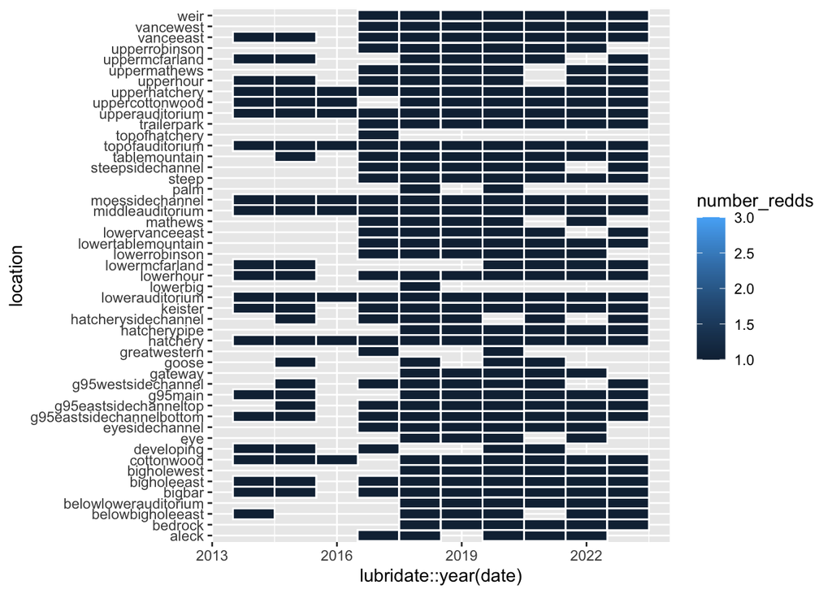

## Map Visuals

The following two maps provide context into the habitat transect locations, identified by whether they are in the high flow “HFC” or low flow “LFC” part of the Feather River. The first map’s transect location size is dependent on number of fish counted at that transect over the course of the sampling period. The second map is filtered to only show transect locations that had fish recorded.

Qualitatively, redds cluster around habitat transect locations and sites where fish were recorded but without consistency.

### Fish Count and Redd Locations

Size of habitat transects (LFC/HFC) are based off number of fish recorded during the sampling period.

[interactive chart not shown]

### Fish Presence and Redd Locations

Habitat transects (LFC/HFC) are only shown for sites that had fish recorded.

[interactive chart not shown]